# Classification of Apple Quality using R

Amrithya Balaji

# References

1. **Plotting graphs** : `https://bookdown.org/yih_huynh/Guide-to-R-Book/other-graphs.html`
2. **Corr Plot** : `https://cran.r-project.org/web/packages/corrplot/vignettes/corrplot-intro.html`
3. **Z-score** : `https://www.analyticsvidhya.com/blog/2021/05/feature-engineering-how-to-detect-and-remove-outliers-with-python-code/`
4. **K-means and PCA** : `https://uc-r.github.io/kmeans_clustering`
5. **Fine tuning** : `https://machinelearningmastery.com/tune-machine-learning-algorithms-in-r/` and `https://www.r-bloggers.com/2021/04/decision-trees-in-r/`

# Apple Quality Dataset Overview

There are 4,001 entries in the Apple Quality Data set, and each one describes a different feature of a single apple. This data set is organized to make it easier to create machine learning models that can evaluate and forecast apple quality based on both chemical and physical traits. The following characteristics allow each entry in the data set to be uniquely identified and quantitatively described. The dataset comprises several key attributes:

1. **A_id (Apple ID)**: Each apple’s unique identifier.
2. **Size**: Reflects the physical dimensions or volume.
3. **Weight**: Mass of each apple, typically measured in grams.
4. **Quality Attributes**:
   1. **Sweetness**: Based on sugar content.
   2. **Crunchiness**: Assessed via mechanical testing.
   3. **Juiciness**: Evaluated by juice yield.
   4. **Ripeness**: Determined through firmness or biochemical markers.
   5. **Acidity**: Acid content affecting flavor.
5. **Quality**: Overall quality classification into ‘good’ or ‘bad’.

# 1. Importing libraries

Our data must be prepared before it is inputted into machine learning models, and the `dplyr` package offers a number of functions for data manipulation while for training and testing machine learning models in R, we use the `caret` package. `ggplot2` and `gridExtra` are used for creating plot and data visualizations. `corrplot` is for correlation plots

To install any package `install.packages("package_name")`

```r
library(caret)
library(dplyr)
library(ggplot2)
library(gridExtra)
library(corrplot)
library(ClusterR)
library(cluster)
library(clue)
library(class)
library(factoextra)
library(tidyverse)
library(pROC)
library(rpart)  # For CART
library(randomForest)
```

# 2.Uploading dataset

The data set is an open-source data set taken from kaggle `https://www.kaggle.com/datasets/nelgiriyewithana/apple-quality`. Here, we have manually downloaded the data set and uploaded it using `read.csv`.You can replace `"your_dataset_location.csv"` with the actual path to your data set file.

```r
apple_quality <- read.csv("A:/learning/sem 2/data mining/project/apple/apple_quality.csv")
```

# 3.Exploratory Data Analysis

Let’s do some data analysis on out apple quality data set that we have.

First,let’s us see the shape of out dataset.

```r
# Finding the shape of the data using dim()
shape <- dim(apple_quality)
print(shape)
```

```
[1] 4001    9
```

To see the head and the summary of out data set

```r
# head() gives us the first few rows of the dataset
head(apple_quality)
```

|  | A_id | Size | Weight | Sweetness | Crunchiness | Juiciness | Ripeness | Acidity | Quality |
| --- | --- | --- | --- | --- | --- | --- | --- | --- | --- |
| 1 | 0 | -3.9700485 | -2.512336 | 5.3463296 | -1.01200871 | 1.8449004 | 0.32983980 | -0.491590483 | good |
| 2 | 1 | -1.1952172 | -2.839257 | 3.6640588 | 1.58823231 | 0.8532858 | 0.86753008 | -0.722809367 | good |
| 3 | 2 | -0.2920239 | -1.351282 | -1.7384292 | -0.34261593 | 2.8386355 | -0.03803333 | 2.621636473 | bad |
| 4 | 3 | -0.6571958 | -2.271627 | 1.3248738 | -0.09787472 | 3.6379705 | -3.41376134 | 0.790723217 | good |
| 5 | 4 | 1.3642168 | -1.296612 | -0.3846582 | -0.55300577 | 3.0308744 | -1.30384943 | 0.501984036 | good |
| 6 | 5 | -3.4253998 | -1.409082 | -1.9135112 | -0.55577486 | -3.8530715 | 1.91461592 | -2.981523169 | bad |

```r
# For basic statistics, we use summary()
summary(apple_quality)
```

```
      A_id             Size             Weight           Sweetness        Crunchiness         Juiciness          Ripeness         Acidity            Quality
 Min.   :   0.0   Min.   :-7.1517   Min.   :-7.14985   Min.   :-6.8945   Min.   :-6.05506   Min.   :-5.9619   Min.   :-5.8646   Length:4001        Length:4001
 1st Qu.: 999.8   1st Qu.:-1.8168   1st Qu.:-2.01177   1st Qu.:-1.7384   1st Qu.: 0.06276   1st Qu.:-0.8013   1st Qu.:-0.7717   Class :character   Class :character
 Median :1999.5   Median :-0.5137   Median :-0.98474   Median :-0.5048   Median : 0.99825   Median : 0.5342   Median : 0.5034   Mode  :character   Mode  :character
 Mean   :1999.5   Mean   :-0.5030   Mean   :-0.98955   Mean   :-0.4705   Mean   : 0.98548   Mean   : 0.5121   Mean   : 0.4983
 3rd Qu.:2999.2   3rd Qu.: 0.8055   3rd Qu.: 0.03098   3rd Qu.: 0.8019   3rd Qu.: 1.89423   3rd Qu.: 1.8360   3rd Qu.: 1.7662
 Max.   :3999.0   Max.   : 6.4064   Max.   : 5.79071   Max.   : 6.3749   Max.   : 7.61985   Max.   : 7.3644   Max.   : 7.2378
 NA's   :1        NA's   :1         NA's   :1          NA's   :1         NA's   :1          NA's   :1         NA's   :1
```

To check the total number of values in each column,

```r
# Checking the total number of values in each column
col_values <- sapply(apple_quality, function(x) length(x))
print(col_values)
```

```
       A_id        Size      Weight   Sweetness Crunchiness   Juiciness    Ripeness     Acidity     Quality
       4001        4001        4001        4001        4001        4001        4001        4001        4001
```

So, we can conclude that each column has same number of values but we also need to check if there are any missing values in each columns.

```r
# Checking if there are any missing values in each columns
missing_values <- colSums(is.na(apple_quality))

print(missing_values)
```

```
       A_id        Size      Weight   Sweetness Crunchiness   Juiciness    Ripeness     Acidity     Quality
          1           1           1           1           1           1           1           0           0
```

There is 1 missing value.Let’s check the tail of the data set which gives us the last few rows of the data set.

```r
# Printing the tail of the data set
tail(apple_quality)
```

|  | A_id | Size | Weight | Sweetness | Crunchiness | Juiciness | Ripeness | Acidity | Quality |
| --- | --- | --- | --- | --- | --- | --- | --- | --- | --- |
| 3996 | 3995 | 0.05938644 | -1.067408 | -3.7145487 | 0.4730517 | 1.69798630 | 2.2440547 | 0.137784369 | bad |
| 3997 | 3996 | -0.29311801 | 1.949253 | -0.2040199 | -0.6401956 | 0.02452263 | -1.0878997 | 1.854235285 | good |
| 3998 | 3997 | -2.63451530 | -2.138247 | -2.4404613 | 0.6572229 | 2.19970859 | 4.7638592 | -1.334611391 | bad |
| 3999 | 3998 | -4.00800374 | -1.779337 | 2.3663970 | -0.2003294 | 2.16143512 | 0.2144884 | -2.229719806 | good |
| 4000 | 3999 | 0.27853965 | -1.715505 | 0.1212173 | -1.1540748 | 1.26667740 | -0.7765715 | 1.599796456 | good |
| 4001 | NA | NA | NA | NA | NA | NA | NA | Created_by_Nidula_Elgiriyewithana |  |

We can see the last row of the dataset is not helpful for us as it just contains the details of author of the data set. So, we can drop the last row and also we check the missing values again after removing the rows.

```r
# na.omit() removes the rows with missing values
apple_quality <- na.omit(apple_quality)
missing_values <- colSums(is.na(apple_quality))
print(missing_values)
```

```
       A_id        Size      Weight   Sweetness Crunchiness   Juiciness    Ripeness     Acidity     Quality
          0           0           0           0           0           0           0           0           0
```

We can also remove column `A_id` as it does not add any valuable information and it is also duplicated.

```r
# Removing the column named "A_id" as it is duplicated
apple_quality <- apple_quality[, !(names(apple_quality) == "A_id")]
head(apple_quality)
```

|  | Size | Weight | Sweetness | Crunchiness | Juiciness | Ripeness | Acidity | Quality |
| --- | --- | --- | --- | --- | --- | --- | --- | --- |
| 1 | -3.9700485 | -2.512336 | 5.3463296 | -1.01200871 | 1.8449004 | 0.32983980 | -0.491590483 | good |
| 2 | -1.1952172 | -2.839257 | 3.6640588 | 1.58823231 | 0.8532858 | 0.86753008 | -0.722809367 | good |
| 3 | -0.2920239 | -1.351282 | -1.7384292 | -0.34261593 | 2.8386355 | -0.03803333 | 2.621636473 | bad |
| 4 | -0.6571958 | -2.271627 | 1.3248738 | -0.09787472 | 3.6379705 | -3.41376134 | 0.790723217 | good |
| 5 | 1.3642168 | -1.296612 | -0.3846582 | -0.55300577 | 3.0308744 | -1.30384943 | 0.501984036 | good |
| 6 | -3.4253998 | -1.409082 | -1.9135112 | -0.55577486 | -3.8530715 | 1.91461592 | -2.981523169 | bad |

We can see the datatypes of each column and the values of column `Acidity` is in `double` but the datatype of `Acidity` is in `character`. So we can convert the datatype of `Acidity` to `double`. We also check for any missing values after our type conversion.

```r
# converting type of Acidity to double
apple_quality$Acidity <- as.numeric(apple_quality$Acidity)
print(typeof(apple_quality$Acidity))
```

```
[1] "double"
```

```r
# Checking if there are any missing values in each columns
missing_values <- colSums(is.na(apple_quality))
print(missing_values)
```

```
       Size      Weight   Sweetness Crunchiness   Juiciness    Ripeness     Acidity     Quality
          0           0           0           0           0           0           0           0
```

### Analyzing values in each feature

First let us convert the column `Quality` from character to binary like giving values to `GOOD = 1` and `BAD = 0`. Converting it to binary will be useful for further data analysis.

```r
# Converting Quality to binary (`GOOD = 1` and `BAD = 0`)
apple_quality$Quality <- ifelse(apple_quality$Quality == "good", 1, 0)
```

Checking the distribution of Quality

```r
# Checking the distribution of Quality
quality_counts <- table(apple_quality$Quality)
print(quality_counts)
```

```
   0    1
1996 2004
```

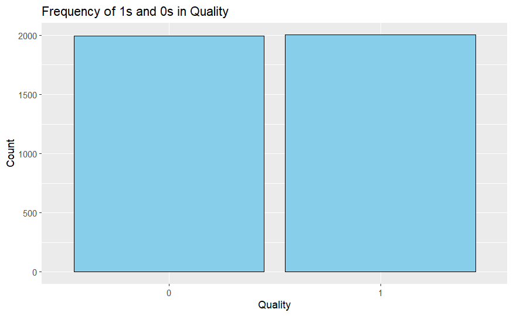

```r
quality_counts_df <- as.data.frame(quality_counts)

names(quality_counts_df) <- c("Quality", "Count")

ggplot(quality_counts_df, aes(x = factor(Quality), y = Count)) +
  geom_bar(stat = "identity", fill = "skyblue", color = "black") +
  labs(title = "Frequency of 1s and 0s in Quality",
       x = "Quality",
       y = "Count")
```

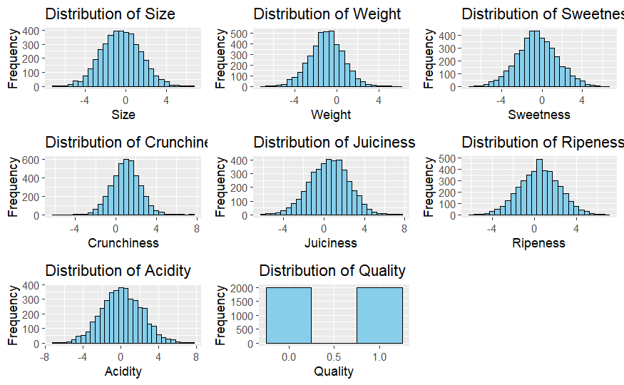

```r
# plot_distribution is used to plot the distribution of values in each column
plot_distribution <- function(data, col_name) {
  if(is.numeric(data[[col_name]])) {
    ggplot(data, aes(x = !!sym(col_name))) +
      geom_histogram(binwidth = 0.5, fill = "skyblue", color = "black") +
      labs(title = paste("Distribution of", col_name),
           x = col_name,
           y = "Frequency")
  } else {
    ggplot(data, aes(x = factor(!!sym(col_name)))) +
      geom_bar(fill = "skyblue", color = "black") +
      labs(title = paste("Distribution of", col_name),
           x = col_name,
           y = "Frequency")
  }
}

for (col_name in names(apple_quality)) {
  plots_list[[col_name]] <- plot_distribution(apple_quality, col_name)
}

grid.arrange(grobs = plots_list, ncol = 3)
```

Plotting correlation matrix for all numeric columns in our data set.

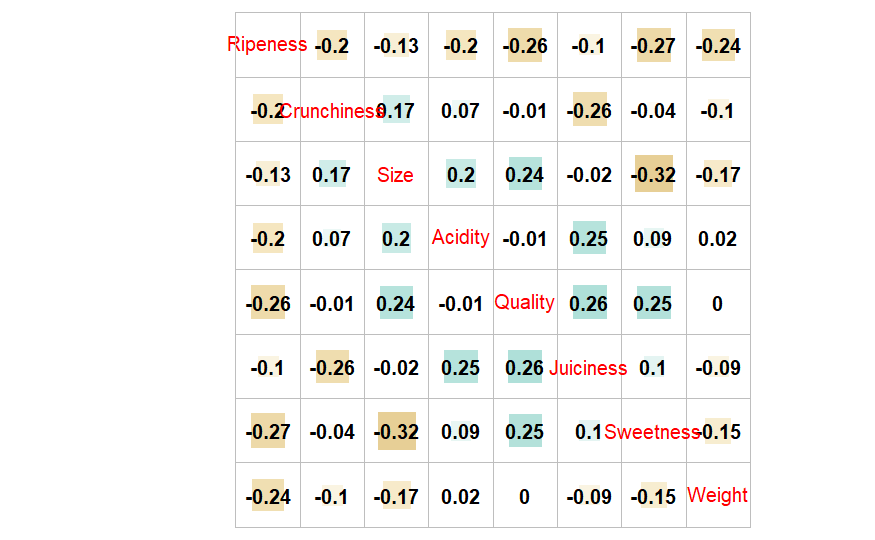

```r
# Plotting correlation matrix for all numeric columns
correlation_matrix <- cor(apple_quality)
corrplot(correlation_matrix, method = 'square', order = 'AOE', addCoef.col = 'black', tl.pos = 'd',
         cl.pos = 'n', col = COL2('BrBG'))
```

Pair wise plotting between all features.

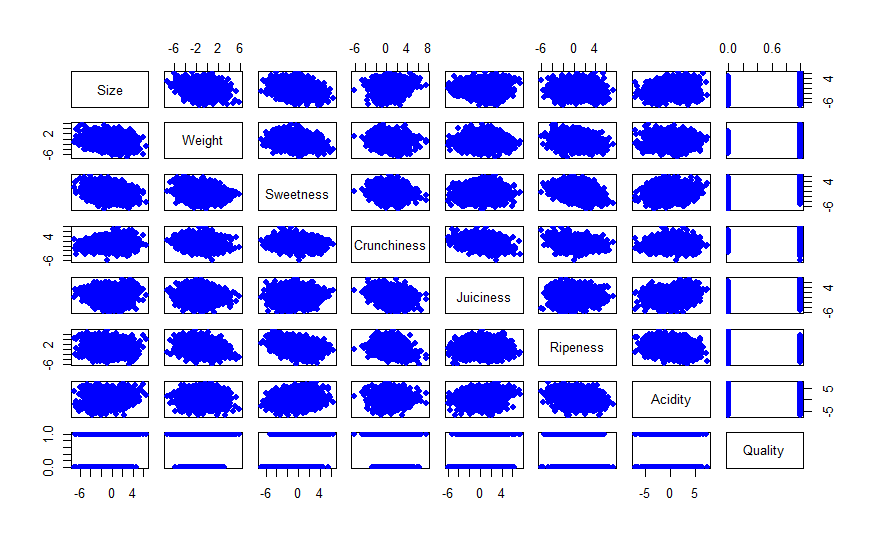

```r
# Pair wise plotting between all features.
pairs(apple_quality, col = "blue", pch = 16, labels = colnames(apple_quality))
```

# 4. Data Preprocessing

The data set is also scaled so we don’t have to scale the values again.We have checked the dataset for missing values and have removed all the rows containing missing values. We also need the data to be noise free and with less outliers.

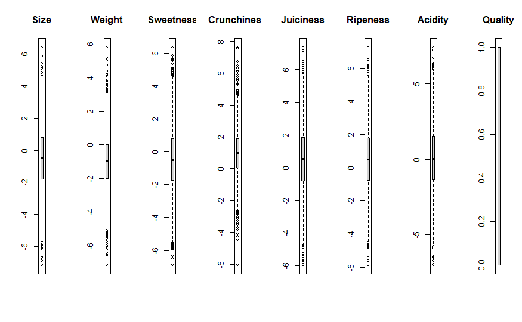

```r
# plotting boxplot to find outliers
par(mfrow=c(1, ncol(apple_quality)))
for(i in 1:ncol(apple_quality)) {
  if(is.numeric(apple_quality[, i])) {
    boxplot(apple_quality[, i], main=names(apple_quality)[i])
  }
}
```

From the above box plot, we can see that there are outliers in our dataset. So we can use z_scores to remove the outliers.

```r
# Removing outliers using Z_Scores
apple_quality <- as.data.frame(apple_quality)
outlier_indices <- list()

for (col_name in names(apple_quality)) {
  z_scores <- scale(apple_quality[[col_name]])
  threshold <- 3
  outliers <- which(abs(z_scores) > threshold)
  outlier_indices[[col_name]] <- outliers
}
all_outliers <- unique(unlist(outlier_indices))
apple_quality <- apple_quality[-all_outliers, ]
```

```r
shape <- dim(apple_quality)
print(shape)
```

```
[1] 3903    8
```

# 5. Modelling

Let us separate the feature and target variables in our data set. We know that the `Quality` is our target variable.

```r
# Separating target and feature variables
target_variable <- apple_quality[, ncol(apple_quality)]
cat("Shape of target_variable: ", length(target_variable), "\n")
```

```
Shape of target_variable:  3903
```

```r
feature_variables <- apple_quality[, -ncol(apple_quality)]

shape_feature_variables <- dim(feature_variables)
cat("Shape of feature_variables:", shape_feature_variables, "\n")
```

```
Shape of feature_variables: 3903 7
```

Splitting the data set into training and test set is an important step for applying out learning models.

```r
# Splitting the dataset into train-test
train_index <- createDataPartition(target_variable, p = 0.8, list = FALSE)
train_data <- apple_quality[train_index, ]
test_data <- apple_quality[-train_index, ]
cat(" Shape of train_data: ", dim(train_data), "\n","Shape of test_data: ", dim(test_data))
```

```
 Shape of train_data:  3123 8
 Shape of test_data:  780 8
```

### KMeans

K-means is a distance- or centroid-based algorithm that uses distance measurements to determine how to assign a point to a cluster. Each cluster in K-Means has a centroid attached to it. Although KMeans is typically applied to unsupervised data, we can cluster our data points to see if they are easily distinguishable from one another. We apply KMeans to the entire data set. We also apply PCA through `fviz_cluster` to visualize out scatter plots. We use silhouette test to see our optimal clusters. We get `K = 2`.

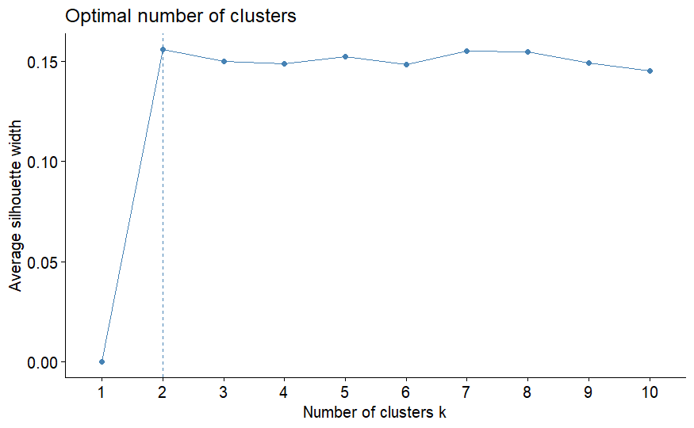

```r
fviz_nbclust(apple_quality, kmeans, method = "silhouette")
```

```r
set.seed(240)  # for reproducibility
apple_quality$Quality <- as.numeric(apple_quality$Quality)
train_data$Quality <-as.numeric(train_data$Quality)
test_data$Quality <-as.numeric(test_data$Quality)

k2 <- kmeans(apple_quality, centers = 2, nstart = 25)
str(k2)
```

```
List of 9
 $ cluster     : Named int [1:3903] 1 1 2 2 2 1 2 1 1 2 ...
  ..- attr(*, "names")= chr [1:3903] "1" "2" "3" "4" ...
 $ centers     : num [1:2, 1:8] -1.022 0.206 -0.982 -1.003 -0.571 ...
  ..- attr(*, "dimnames")=List of 2
  .. ..$ : chr [1:2] "1" "2"
  .. ..$ : chr [1:8] "Size" "Weight" "Sweetness" "Crunchiness" ...
 $ totss       : num 89329
 $ withinss    : num [1:2] 43248 31775
 $ tot.withinss: num 75023
 $ betweenss   : num 14306
 $ size        : int [1:2] 2282 1621
 $ iter        : int 1
 $ ifault      : int 0
 - attr(*, "class")= chr "kmeans"
```

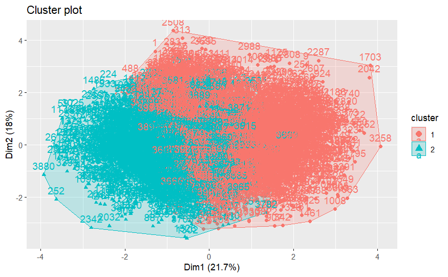

```r
fviz_cluster(k2, data = apple_quality)
```

```r
head(apple_quality)
```

|  | Size | Weight | Sweetness | Crunchiness | Juiciness | Ripeness | Acidity | Quality |
| --- | --- | --- | --- | --- | --- | --- | --- | --- |
| 1 | -3.9700485 | -2.512336 | 5.3463296 | -1.01200871 | 1.8449004 | 0.32983980 | -0.4915905 | 1 |
| 2 | -1.1952172 | -2.839257 | 3.6640588 | 1.58823231 | 0.8532858 | 0.86753008 | -0.7228094 | 1 |
| 3 | -0.2920239 | -1.351282 | -1.7384292 | -0.34261593 | 2.8386355 | -0.03803333 | 2.6216365 | 0 |
| 4 | -0.6571958 | -2.271627 | 1.3248738 | -0.09787472 | 3.6379705 | -3.41376134 | 0.7907232 | 1 |
| 5 | 1.3642168 | -1.296612 | -0.3846582 | -0.55300577 | 3.0308744 | -1.30384943 | 0.5019840 | 1 |
| 6 | -3.4253998 | -1.409082 | -1.9135112 | -0.55577486 | -3.8530715 | 1.91461592 | -2.9815232 | 0 |

```r
NA
```

We can clearly see that the apple quality is not distinguishable from each other.Still, we can see how it performs on our `test_set`. We again perform PCA and we also calculate the number of principal components to retain based on the cumulative explained variance threshold.

```r
feature_train_data <- train_data[, !names(train_data) %in% "Quality"]
pca_result <- prcomp(feature_train_data, center = TRUE, scale. = TRUE)
summary(pca_result)
```

```
Importance of components:
                          PC1    PC2    PC3    PC4    PC5     PC6     PC7
Standard deviation     1.2319 1.1947 1.1109 1.0728 0.8582 0.78883 0.55796
Proportion of Variance 0.2168 0.2039 0.1763 0.1644 0.1052 0.08889 0.04447
Cumulative Proportion  0.2168 0.4207 0.5970 0.7614 0.8666 0.95553 1.00000
```

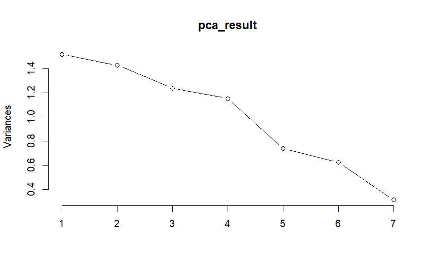

```r
plot(pca_result, type = "lines")
```

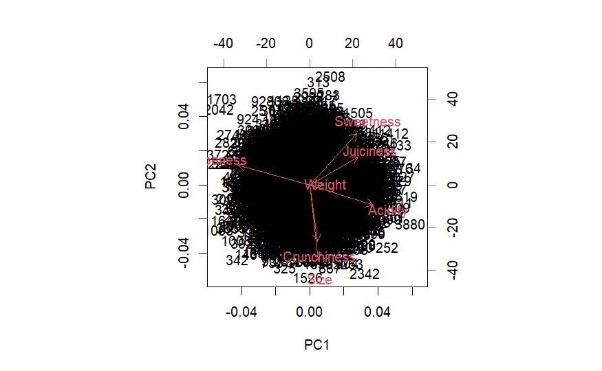

```r
biplot(pca_result)
```

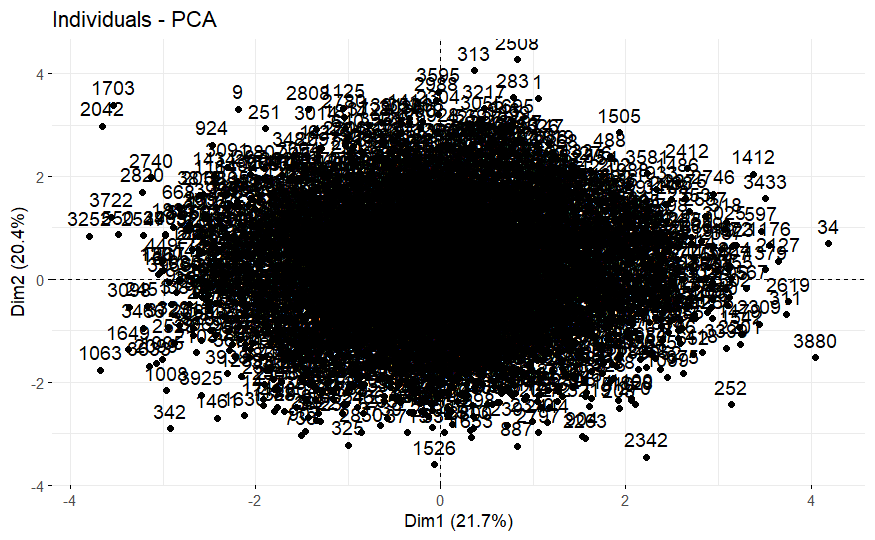

```r
fviz_pca_ind(pca_result)
```

```r
pca_scores <- pca_result$x
```

```r
explained_variance <- summary(pca_result)$importance[2,]
cum_explained_variance <- cumsum(explained_variance)
num_components <- which(cum_explained_variance >= 0.8)[1]
pca_scores <- pca_result$x[, 1:num_components]
```

To perform on the `test_data`, we assign clusters using the centroids from the KMeans model of the training data and this finds the nearest centroid for each point in the test data where we calculate distances from the point to each cluster center. `get_cluster_assignment` is used to calculate the distance to the cluster centers. We already know the labels of the clusters that is `Cluster 1 is Good/1` and `Cluster 2 is Bad/0`.So, we get the predicted clusters and use that to predict our apple quality.

```r
feature_test_data <- test_data[, !names(test_data) %in% "target_variable"]

test_data_pca <- predict(pca_result, newdata = feature_test_data)

test_data_pca <- test_data_pca[, 1:num_components]

get_cluster_assignment <- function(point, centers) {
  distances <- apply(centers, 1, function(center) sum((point - center)^2))
  return(which.min(distances))
}

suppressWarnings(test_clusters <- apply(test_data_pca, 1, get_cluster_assignment, centers = kmeans_result$centers))

test_data$predicted_cluster <- test_clusters
test_data$Quality_predicted <- ifelse(test_data$predicted_cluster == 1, 1, 0)

true_clusters <- test_data$cluster # replace with your actual true cluster column name
accuracy <- mean(test_data$Quality == test_data$Quality_predicted)
cat("Accuracy of cluster prediction on test data:", accuracy)
```

```
Accuracy of cluster prediction on test data: 0.6307692
```

```r
confusion_matrix <- table(test_data$Quality,test_data$Quality_predicted)
tp <- confusion_matrix[2, 2] #true_positive
fp <- confusion_matrix[1, 2] #false_positive
fn <- confusion_matrix[2, 1] #false_negative
precision <- tp / (tp + fp)
recall <- tp / (tp + fn)
f1_score <- 2 * precision * recall / (precision + recall)
cat("Confusion_matrix: ",confusion_matrix,"\n")
```

```
Confusion_matrix:  241 142 146 251
```

```r
cat("F1 Score for Kmeans: ", f1_score, "\n")
```

```
F1 Score for Kmeans:  0.635443
```

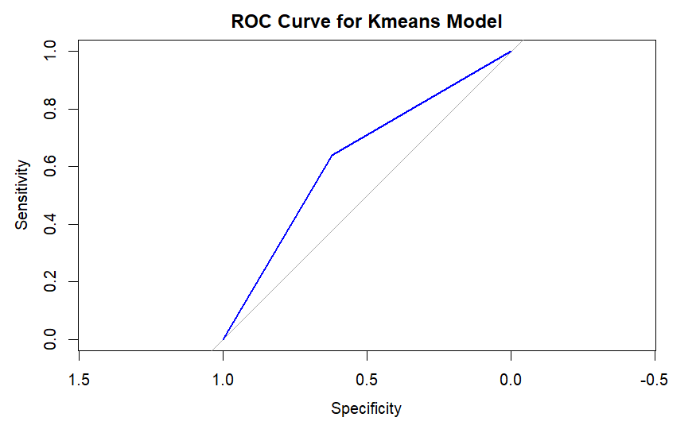

```r
roc_curve <- roc(test_data$Quality, as.numeric(test_data$Quality_predicted))
plot(roc_curve, main = "ROC Curve for Kmeans Model", col = "blue", lwd = 2)
```

The accuracy is very low as expected. So, we will try to implement other model through KNN

### KNN

```r
train_data <- apple_quality[train_index, ]
test_data <- apple_quality[-train_index, ]
head(train_data)
```

|  | Size | Weight | Sweetness | Crunchiness | Juiciness | Ripeness | Acidity | Quality |
| --- | --- | --- | --- | --- | --- | --- | --- | --- |
| 1 | -3.9700485 | -2.5123364 | 5.3463296 | -1.01200871 | 1.844900 | 0.3298398 | -0.4915905 | 1 |
| 4 | -0.6571958 | -2.2716266 | 1.3248738 | -0.09787472 | 3.637970 | -3.4137613 | 0.7907232 | 1 |
| 5 | 1.3642168 | -1.2966119 | -0.3846582 | -0.55300577 | 3.030874 | -1.3038494 | 0.5019840 | 1 |
| 6 | -3.4253998 | -1.4090822 | -1.9135112 | -0.55577486 | -3.853071 | 1.9146159 | -2.9815232 | 0 |
| 7 | 1.3316057 | 1.6359557 | 0.8759742 | -1.67779794 | 3.106344 | -1.8474167 | 2.4141705 | 1 |
| 8 | -1.9954621 | -0.4289585 | 1.5306436 | -0.74297168 | 0.158834 | 0.9744379 | -1.4701251 | 1 |

```r
head(test_data)
```

|  | Size | Weight | Sweetness | Crunchiness | Juiciness | Ripeness | Acidity | Quality |
| --- | --- | --- | --- | --- | --- | --- | --- | --- |
| 2 | -1.1952172 | -2.8392565 | 3.6640588 | 1.5882323 | 0.8532858 | 0.86753008 | -0.7228094 | 1 |
| 3 | -0.2920239 | -1.3512820 | -1.7384292 | -0.3426159 | 2.8386355 | -0.03803333 | 2.6216365 | 0 |
| 11 | -2.6993363 | -1.3295070 | -1.4185069 | -0.6255458 | 2.3710744 | 3.40316452 | -2.8108082 | 0 |
| 13 | -0.1708117 | -1.8672711 | -1.7718447 | 2.4131553 | -3.0945547 | -0.62488438 | -2.0761140 | 0 |
| 15 | 2.8395809 | -0.3447982 | -1.0197973 | 0.8945809 | -1.3000609 | 0.58237862 | 1.7097082 | 1 |
| 25 | 0.5229608 | -1.4280852 | -0.7435187 | 1.7867162 | -4.2075435 | -1.82523122 | -1.4304299 | 0 |

KNN is a simple algorithm which classifies or predicts how a single data point will be grouped based on proximity. We do hyper-parameter tuning to see which `K` value performs well. We take values as `k = 1:10`. We can see the accuracies are stable with the values of `k=6,7,8`. So we can take the optimal value of `k=7`.

```r
train_data$Quality <- as.factor(train_data$Quality)
test_data$Quality <- as.factor(test_data$Quality)

knn_results <- train(Quality ~ ., data = train_data, method = "knn",
                     trControl = train_control,
                     preProcess = "scale",
                     tuneGrid = expand.grid(k = 1:10))

# Extract accuracies and corresponding k values
results <- knn_results$results
k_values <- results$k
accuracies <- results$Accuracy

print(accuracies)
```

```
 [1] 0.8789901 0.8728993 0.8914707 0.8895496 0.8956405 0.8898671 0.8943440 0.8917933 0.8953179 0.8972441
```

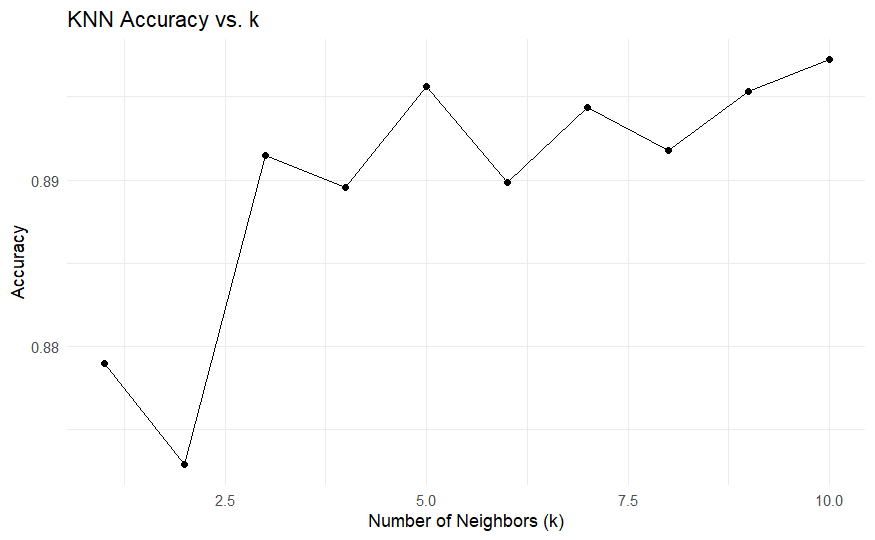

```r
# Create a data frame for plotting
plot_data <- data.frame(k = k_values, Accuracy = accuracies)

# Plot accuracy vs k
ggplot(plot_data, aes(x = k, y = Accuracy)) +
    geom_line() +
    geom_point(shape = 19) +
    labs(title = "KNN Accuracy vs. k",
         x = "Number of Neighbors (k)",
         y = "Accuracy") +
    theme_minimal()
```

```r
train_control <- trainControl(method = "cv", number = 10)  # 10-fold cross-validation

# Train the model using k = 7
knn_model <- train(Quality ~ ., data = train_data, method = "knn",
                   trControl = train_control,
                   preProcess = "scale",  # Ensure features are scaled
                   tuneGrid = data.frame(k = 7))  # Using k = 7
predictions <- predict(knn_model, newdata = test_data)
accuracy <- sum(predictions == test_data$Quality) / nrow(test_data)
cat("Accuracy of the KNN model with k=7: ", accuracy * 100, "%\n")
```

```
Accuracy of the KNN model with k=7:  88.84615 %
```

```r
confusion_matrix <- table(predictions, test_data$Quality)
tp <- confusion_matrix[2, 2] #true_positive
fp <- confusion_matrix[1, 2] #false_positive
fn <- confusion_matrix[2, 1] #false_negative
precision <- tp / (tp + fp)
recall <- tp / (tp + fn)
f1_score <- 2 * precision * recall / (precision + recall)
cat("Confusion_matrix: ",confusion_matrix,"\n")
```

```
Confusion_matrix:  336 51 36 357
```

```r
cat("F1 Score: ", f1_score, "\n")
```

```
F1 Score:  0.8913858
```

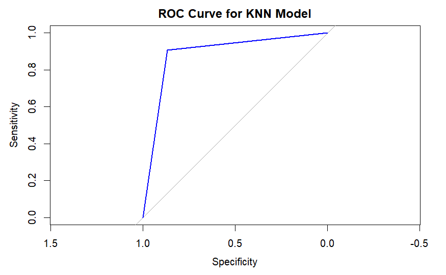

```r
roc_curve <- roc(test_data$Quality, as.numeric(predictions))
plot(roc_curve, main = "ROC Curve for KNN Model", col = "blue", lwd = 2)
```

KNN performs very well with the `accuracy of 88 to 90%` on our `test_data`

### Decision Tree

```r
control <- trainControl(method="repeatedcv", number=10, repeats=3, search="random")
metric <- "Accuracy"
mtry <- sqrt(ncol(train_data))
dt_random <- train(Quality ~., data=train_data, method="rpart", metric=metric, tuneLength=15, trControl=control)
print(dt_random)
```

```
CART

3123 samples
   7 predictor
   2 classes: '0', '1'

No pre-processing
Resampling: Cross-Validated (10 fold, repeated 3 times)
Summary of sample sizes: 2811, 2811, 2811, 2810, 2810, 2811, ...
Resampling results across tuning parameters:

  cp           Accuracy   Kappa
  0.001131953  0.8043553  0.6087403
  0.001293661  0.8042495  0.6085314
  0.001423027  0.8042495  0.6085314
  0.002263907  0.8012587  0.6025797
  0.002802932  0.7983772  0.5968052
  0.003880983  0.7872797  0.5746139
  0.004527814  0.7846146  0.5692456
  0.005821475  0.7748947  0.5497846
  0.006144890  0.7739359  0.5478503
  0.006791721  0.7691340  0.5382140
  0.007761966  0.7646489  0.5291883
  0.013906856  0.7367851  0.4733648
  0.018326865  0.7188640  0.4376840

Accuracy was used to select the optimal model using the largest value.
The final value used for the model was cp = 0.001131953.
```

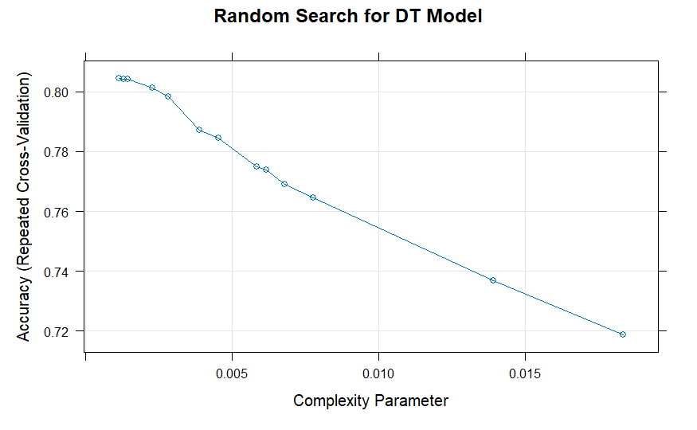

```r
plot(dt_random,main = "Random Search for DT Model")
```

```r
test_predictions <- predict(dt_random, newdata = test_data, type = "raw", cp=0.001611863)

# Evaluate accuracy
accuracy <- mean(test_predictions == test_data$Quality)
cat("Accuracy of DT:", accuracy)
```

```
Accuracy of DT: 0.8217949
```

```r
confusion_matrix <- table(test_predictions, test_data$Quality)

tp <- confusion_matrix[2, 2] #true_positive
fp <- confusion_matrix[1, 2] #false_positive
fn <- confusion_matrix[2, 1] #false_negative
precision <- tp / (tp + fp)
recall <- tp / (tp + fn)
f1_score <- 2 * precision * recall / (precision + recall)
cat("\nConfusion_matrix for DT: ",confusion_matrix,"\n")
```

```
Confusion_matrix for DT:  313 74 65 328
```

```r
cat("F1 Score for DT: ", f1_score, "\n")
```

```
F1 Score for DT:  0.8251572
```

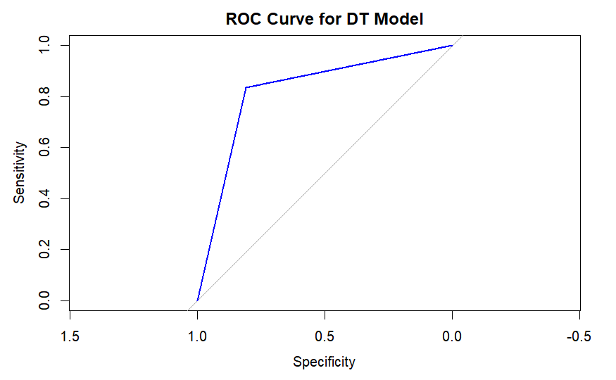

```r
roc_curve <- roc(test_data$Quality, as.numeric(test_predictions))
plot(roc_curve, main = "ROC Curve for DT Model", col = "blue", lwd = 2)
```

### Random forest

```r
# Random Search
control <- trainControl(method="repeatedcv", number=10, repeats=3, search="random")
metric <- "Accuracy"
mtry <- sqrt(ncol(train_data))
rf_random <- train(Quality ~., data=train_data, method="rf", metric=metric, tuneLength=15, trControl=control)
print(rf_random)
```

```
Random Forest

3123 samples
   7 predictor
   2 classes: '0', '1'

No pre-processing
Resampling: Cross-Validated (10 fold, repeated 3 times)
Summary of sample sizes: 2810, 2812, 2810, 2811, 2810, 2812, ...
Resampling results across tuning parameters:

  mtry  Accuracy   Kappa
  1     0.8816293  0.7632908
  2     0.8840870  0.7682015
  3     0.8845123  0.7690518
  6     0.8792813  0.7585787
  7     0.8785351  0.7570913

Accuracy was used to select the optimal model using the largest value.
The final value used for the model was mtry = 3.
```

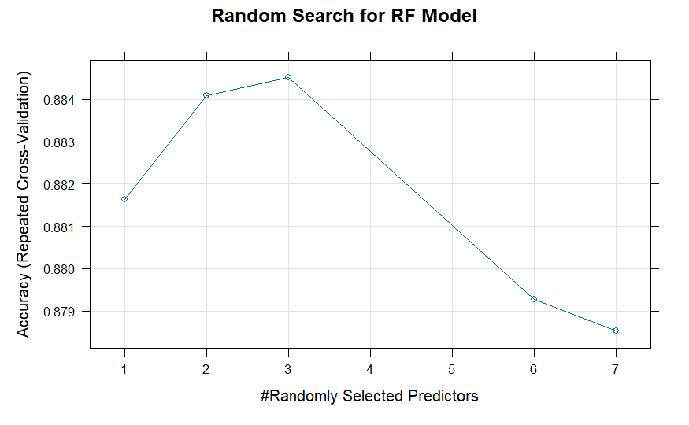

```r
plot(rf_random,main = "Random Search for RF Model")
```

```r
test_predictions <- predict(rf_random, newdata = test_data, type = "raw", ntree=4)

# Evaluate accuracy
accuracy <- mean(test_predictions == test_data$Quality)
cat("Accuracy of the Random forest with ntree = 4:", accuracy)
```

```
Accuracy of the Random forest with ntree = 4: 0.8858974
```

```r
confusion_matrix <- table(test_predictions, test_data$Quality)

tp <- confusion_matrix[2, 2] #true_positive
fp <- confusion_matrix[1, 2] #false_positive
fn <- confusion_matrix[2, 1] #false_negative
precision <- tp / (tp + fp)
recall <- tp / (tp + fn)
f1_score <- 2 * precision * recall / (precision + recall)
cat("\nConfusion_matrix: ",confusion_matrix,"\n")
```

```
Confusion_matrix:  330 57 32 361
```

```r
cat("F1 Score: ", f1_score, "\n")
```

```
F1 Score:  0.8902589
```

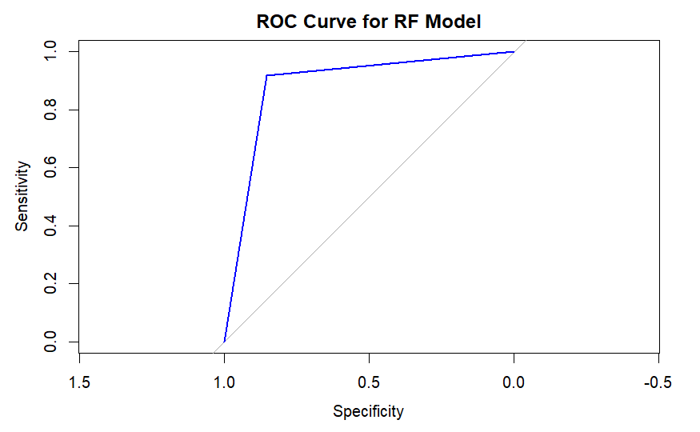

```r
roc_curve <- roc(test_data$Quality, as.numeric(test_predictions))
plot(roc_curve, main = "ROC Curve for RF Model", col = "blue", lwd = 2)
```

Model summary is presented below. We can see `KNN` performs well with better `Accuracy` and `F1 score`

[output not shown]